# **Final Report for DataScience Capstone**

Word prediction with Natural Language Processing

Chris McKelt

December 2017

## Introduction

This report outlines the methodology for building a word prediction application using Natural Language Processing techniques as part of the the [Coursera Data Science Specialization](https://www.coursera.org/specializations/jhu-data-science).

The essence of the Capstone project is to create an application that uses NLP techniques and predictive analytics, and like SwiftKey’s applications, takes in a word phrase and returns next-predicted word.

The [milestone report](http://chrismckelt.github.io/r-course/10-capstone/milestone/milestone-report.html) outlines the initial approach to building a series of [ngram models](https://en.wikipedia.org/wiki/N-gram) from a range of text documents.

## Overview of the application

The application was developed in R using a number of packages and the Shiny web framework. Below outlines the methodology used to build,predict and evaluate the application.

#### NGram model

```
1. Sample text taken from SwiftKey corpus data (15% of original)
2. The text was cleaned from non-ASCII characters, derogatory language, punctuation, non words and   extra whitespace
3. The corpus was processed to produce 5 ngram models which were morphed into a data table together with the totalled frequence of the ngram (bag of words).
```

## Prediction

A prediction function then takes a sentence as input and execute the below steps 1. Validates and clean the input sentence (using the same ‘clean_text’ function to build the ngram models) 2. For each ngram gram model take the N last words for the input text where N is the size-1 of the ngram model. For example:

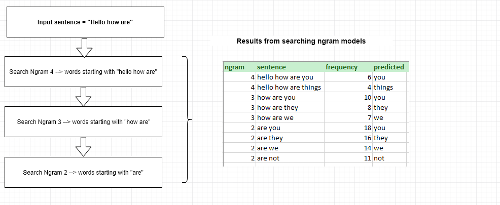

#### Description of the algorithm used to make the prediction

With a data table containing the ngram model, sentence, frequency and predicted word, the top 3 most probable words are predicted using a [Stupid Backoff](http://www.aclweb.org/anthology/D07-1090.pdf) smoothing strategy.

A pseudo code description to calculate the ‘score’ for each word follows:

```
if the rows ngram model was 5

  score = matched 5 gram Count / input 4 gram Count

else if the rows ngram model was 4

  score = 0.4 * matched 4 gram Count / input 3 gram Count

else if the rows ngram model was 3

  score = 0.4 * 0.4 * matched 3 gram Count / input 2 gram Count

else if the rows ngram model was 2

  score = 0.4 * 0.4 * 0.4 * matched 2 gram Count / input 1 gram Count
```

Finally we group and sum similar words

For example if the predicted word ‘you’ was found in ngram 4 (and thus ngram 3 & 2) it may look like

| ngram | predicted | score |  |
| --- | --- | --- | --- |
| 4 | you | 0.2 |  |
| 3 | you | 0.1 |  |
| 2 | you | 0.05 |  |

The total score for the predicted word ‘you’ is (0.2 + 0.1 + 0.05) = 0.35

The final scoring is aggregated and summed for each word. The top 3 words are selected according to the highest score.

When no results are found the 3 most common words from the English language (‘the’, ‘be’, ‘to’) are returned as a response.

## Evaluation

The prediction model was evaluated using the Benchmark.R tool (see references for source).

Initial predicts were quite high but also quite slow. The decision to only using 1-3 ngram models to speed up the search cut the time in half and only dropped the accuracy by 10%.

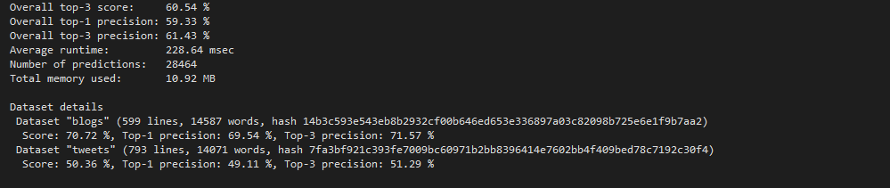

## Instructions

To use the application navigate to the following URL

https://chrismckelt.shinyapps.io/datascience-capstone/

Start typing in text

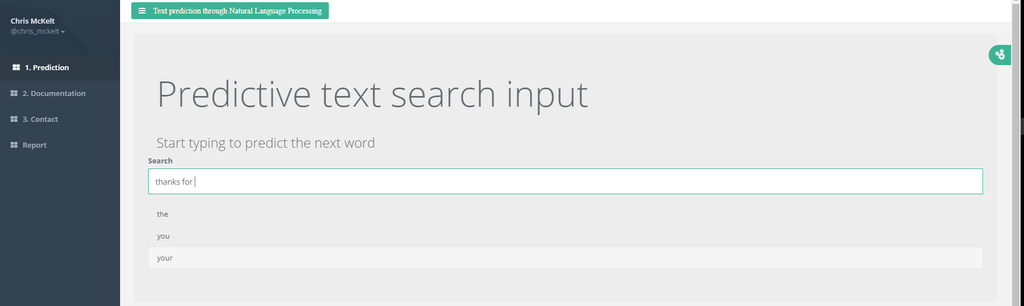

For access to the code please contact the author using one of the contact links on the site.

## References

[Speech and Language Processing, by D. Jurafsky & al, Chapter 4, Draft of January 9, 2015](https://web.stanford.edu/~jurafsky/slp3/)

[JHU DS Capstone Swiftkey Dataset](https://d396qusza40orc.cloudfront.net/dsscapstone/dataset/Coursera-SwiftKey.zip)

[Large language models in machine translation by T. Brants et al, in EMNLP/CoNLL 2007](http://www.aclweb.org/anthology/D07-1090.pdf)

[Next word prediction benchmark](https://github.com/hfoffani/dsci-benchmark)